# MSDA IS607- Project - Consumer Complaints against Financial Products

Shipra Ahuja  
17th Dec,2014

### Motivation

Many of us face several issues with financial products offered by various financial institutions and end up calling their customer care centers spending hours together sometimes. So when I saw this consumer complaints data openly available, I was motivated to perform the below analysis -

- Financial Products - Top grabbers of complaints
- States - Where maximum complaints are filed
- Companies - Notorious receiving large number of complaints
- Yearly trend of complaints
- Monthly Average of number of complaints for each year
- Peek into company responses - Closed, In progress, Untimely responses

### What Financial Products?

- Bank accounts or services
- Consumer loans
- Credit cards
- Credit reporting
- Debt collection
- Money transfers
- Mortgages
- Private student loans
- Payday loans

### Financial Products - Top number of complaints

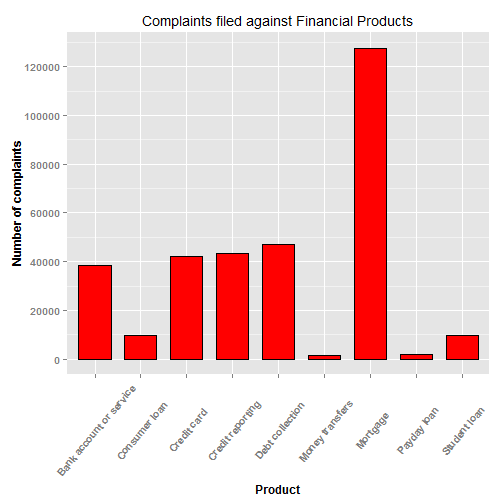

### States with maximum complaints

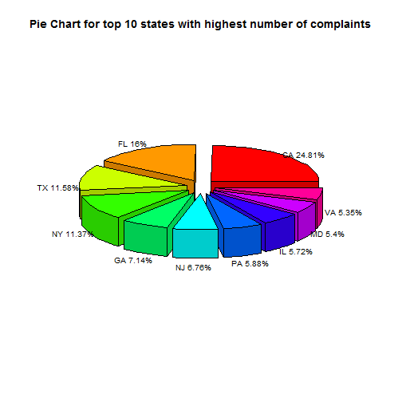

### Top 10 notorious companies

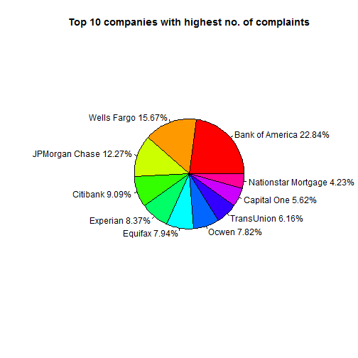

### Yearly trend of complaints

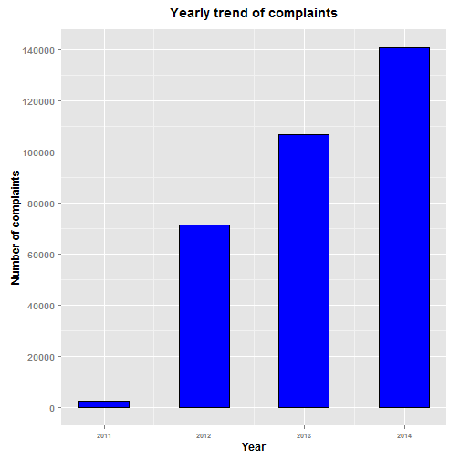

### Monthly average of complaints

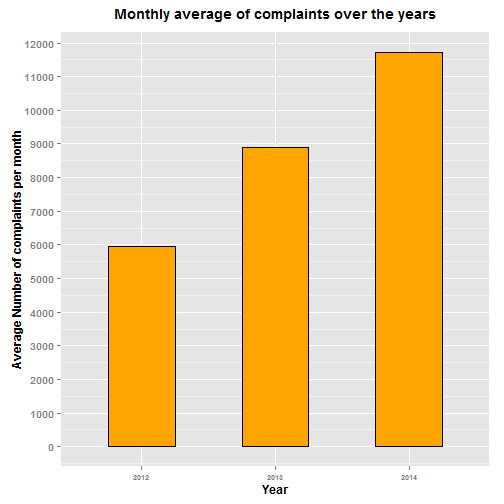

### Peek into company responses for the complaints filed

```
        Response         Product Complaints
1         Closed        Mortgage       3240
47   In progress        Mortgage        994
56 Untimely Resp Debt collection        443
```

### Challenges faced

- CSV File would not get downloaded from the specified link when doing so in R Markdown. Kept getting “Unsupported URL scheme” error. Surprisingly, the file was getting downloaded using R console which added to the confusion

Resolution - “setInternet2(use = TRUE)” in R Markdown

- Issue with UTF-8 unicode characters in the data. They are not setup for use with R Markdown/Latex.

Resolution - Substitute those characters using regular alphabets. Example - LATIN CAPITAL LETTER A WITH CIRCUMFLEX had to be replaced to 'A' during data cleanup

### Highlights

- Created this slideshow in R.

### Conclusion

- Number of complaints - Highest for “Mortgages” followed by Debt Collection, Credit Reporting, Credit Card, Bank Accounts/Services
- Number of complaints filed in a state are directly proportional to the population of the state
- Big banks have a large customer base which possibly is the major reason for more number of complaints against financial products offered by them
- Complaints have shown an increasing trend over the years & are highest in 2014
- Mortgages have the highest Open & Closed complaints and Debt Collection has highest untimely company responses